# Pleiotropy simulations

```r
library(simulateGP)
library(tidyverse)
library(lavaan)
library(RadialMR)
library(pbapply)
library(TwoSampleMR)
library(pROC)
```

# Basic simulation setup

This function does the following

1. For each population make a genetic map for all instruments - independent allele frequencies per SNP and population
2. Generate SNP-exposure effects for pop 1 based on h2 and S
3. Transfer the same SNP-exposure effects to pop 2 (the h2 might be different because the allele frequencies are independent)
4. Create SNP-outcome effects for pop1 and pop2 given the causal effects `biv1` and `biv2` and the horizontal pleiotropic effects `pl1` and `pl2`
5. Generate genetic summary data for exposure and outcome traits for pop1 and pop2 given sample sizes `nid1x`, `nid2x`, `nid1y` and `nid2y`
6. Estimate causal relationships in each population using
- IVW for each pop
- Radial MR for each pop
- `UnweightedSEMa` = SEM where biv1=biv2
- `UnweightedSEMb` = SEM where biv1 and biv2 can vary
- `RadialSEMa` = SEM in a radialMR framework, e.g. allowing it to be weighted, where biv1=biv2
- `RadialSEMb` = SEM in a radialMR framework, e.g. allowing it to be weighted, where biv1 and biv2 can vary

```r
sim1 <- function(nsnp, nid1x, nid2x, nid1y, nid2y, h2, S, biv1, biv2, pl1, pl2, absx, gx_same=TRUE, instrument_threshold=1, winnerscurse_adjustment=FALSE)
{
    # Create map of variants
    map1 <- tibble(snp=1:nsnp, af=runif(nsnp, 0.05, 0.95))
    map2 <- tibble(snp=1:nsnp, af=runif(nsnp, 0.05, 0.95))

    # Create SNP-exposure effects
    x1 <- generate_gwas_params(map1, h2=h2, Pi=1, S=S)
    if(absx)
    {
        x1$beta <- abs(x1$beta)
    }
    x2 <- map2
    if(gx_same)
    {
    x2$beta <- x1$beta
    } else {
      x2 <- generate_gwas_params(map2, h2=h2, Pi=1, S=S)
    }

    # Create SNP-outcome effects
    y1 <- x1
    y1$beta <- y1$beta * biv1 + pl1
    y2 <- x2
    y2$beta <- y2$beta * biv2 + pl2

    x1s <- generate_gwas_ss(x1, nid=nid1x)
    x2s <- generate_gwas_ss(x2, nid=nid2x)
    y1s <- generate_gwas_ss(y1, nid=nid1y)
    y2s <- generate_gwas_ss(y2, nid=nid2y)

    sig <- x1s$pval < instrument_threshold | x2s$pval < instrument_threshold

    x1s <- x1s[sig,]
    x2s <- x2s[sig,]
    y1s <- y1s[sig,]
    y2s <- y2s[sig,]

    x1 <- x1[sig,]
    x2 <- x2[sig,]
    y1 <- y1[sig,]
    y2 <- y2[sig,]

    if(winnerscurse_adjustment)
    {
      x1s$bhat <- rnorm(sum(sig), x1$beta, x1s$se)
      x2s$bhat <- rnorm(sum(sig), x2$beta, x2s$se)
    }

    dat <- tibble(
        y1 = y1s$bhat,
        y2 = y2s$bhat,
        x1 = x1s$bhat,
        x2 = x2s$bhat,
        yse1 = y1s$se,
        yse2 = y2s$se,
        xse1 = x1s$se,
        xse2 = x2s$se,
        r1 = y1/x1,
        r2 = y2/x2,
        w1 = sqrt(x1^2 / yse1^2),
        w2 = sqrt(x2^2 / yse2^2),
        o1 = r1 * w1,
        o2 = r2 * w2
    )

    out <- list()
    out$ivw1 <- TwoSampleMR::mr_ivw(dat$x1, dat$y1, dat$xse1, dat$yse1) %>%
      {tibble(model="IVW", pop=1, bivhat=.$b, se=.$se, pval=.$pval)}
    out$ivw2 <- TwoSampleMR::mr_ivw(dat$x2, dat$y2, dat$xse2, dat$yse2) %>%
      {tibble(model="IVW", pop=2, bivhat=.$b, se=.$se, pval=.$pval)}
    out$rm1 <- summary(lm(o1 ~ -1 + w1, data=dat)) %>%
      {tibble(model="RadialIVW", pop=1, bivhat=.$coef[1,1], se=.$coef[1,2], pval=.$coef[1,4])}
    out$rm2 <- summary(lm(o2 ~ -1 + w2, data=dat)) %>%
      {tibble(model="RadialIVW", pop=2, bivhat=.$coef[1,1], se=.$coef[1,2], pval=.$coef[1,4])}


    runsem <- function(model, data, modname)
    {
      mod <- sem(model, data=data)
      invisible(capture.output(mod <- summary(mod, fit.measures=TRUE)))
      tibble(
        model=modname,
        pop=1:2,
        bivhat=mod$PE$est[1:2],
        se=mod$PE$se[1:2],
        pval=mod$PE$pvalue[1:2],
        aic=mod$FIT['aic']
      )
    }

    out$semA <- runsem('
    y1 ~ biv*x1
    y2 ~ biv*x2
    ', dat, "UnweightedSEMa")

    out$semB <- runsem('
    y1 ~ biv_1*x1
    y2 ~ biv_2*x2
    ', dat, "UnweightedSEMb")

    out$modC <- runsem('
    o1 ~ biv*w1
    o2 ~ biv*w2
    ', dat, "RadialSEMa")

    out$modD <- runsem('
    o1 ~ biv_1*w1
    o2 ~ biv_2*w2
    ', dat, "RadialSEMb")

  compare_est <- function(y, s)
  {
    k <- length(y)
    w <- 1/s^2
    sum.w <- sum(w)
    mu.hat <- sum(y * w)/sum.w
    Q <- sum(w * (y - mu.hat)^2)
    return(Q)
  }

    res <- out %>% bind_rows()

    m1 <- lapply(c("IVW", "RadialIVW"), function(x)
    {
      subset(res, model==x) %>%
        {
          compare_est(.$bivhat[1:2], .$se[1:2])
        } %>%
        {tibble(model=x, stat=.)}
    }) %>% bind_rows()

    m2 <- tibble(model="RadialSEM", stat=subset(res, model=="RadialSEMa" & pop==1)$aic - subset(res, model=="RadialSEMb" & pop==1)$aic)
    m3 <- tibble(model="UnweightedSEM", stat=subset(res, model=="UnweightedSEMa" & pop==1)$aic - subset(res, model=="UnweightedSEMb" & pop==1)$aic)

    popdiff <- bind_rows(m1, m2, m3)

    return(list(dat=dat, res=res, popdiff=popdiff))
}
```

Example simulation

```r
out <- sim1(
  nsnp=100,
  nid1x=10000,
  nid2x=10000,
  nid1y=10000,
  nid2y=10000,
  h2=0.3,
  S=0,
  biv1=0.2,
  biv2=0.2,
  pl1=0,
  pl2=0,
  absx=FALSE
)
```

What does the data look like:

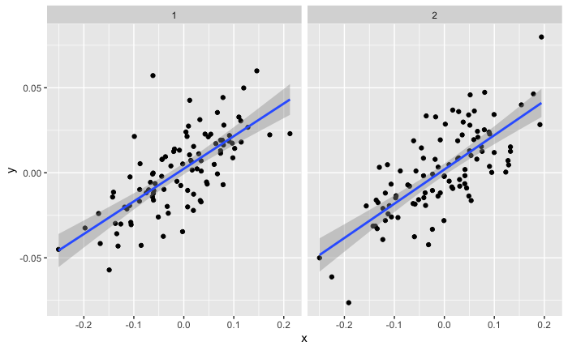

```r
out$dat %>%
  {bind_rows(
    tibble(pop=1, x=.$x1, y=.$y1),
    tibble(pop=2, x=.$x2, y=.$y2)
  )} %>%
  ggplot(., aes(x=x, y=y)) +
    geom_point() +
    geom_smooth(method=lm) +
    facet_grid(. ~ pop)
```

i.e. no directional pleiotropy (slope passes through origin). Estimates:

```r
out$res
```

| model | pop | bivhat | se | pval | aic |
| --- | --- | --- | --- | --- | --- |
| IVW | 1 | 0.1936451 | 0.01843827 | 8.425753e-26 | NA |
| IVW | 2 | 0.2035629 | 0.01856642 | 5.690515e-28 | NA |
| RadialIVW | 1 | 0.1936451 | 0.01686274 | 6.582802e-20 | NA |
| RadialIVW | 2 | 0.2035629 | 0.01856642 | 8.737014e-19 | NA |
| UnweightedSEMa | 1 | 0.1972328 | 0.01273087 | 0.000000e+00 | -1060.2684 |
| UnweightedSEMa | 2 | 0.1972328 | 0.01273087 | 0.000000e+00 | -1060.2684 |
| UnweightedSEMb | 1 | 0.1920246 | 0.01894779 | 0.000000e+00 | -1058.4060 |
| UnweightedSEMb | 2 | 0.2023862 | 0.01882972 | 0.000000e+00 | -1058.4060 |
| RadialSEMa | 1 | 0.1978930 | 0.02042167 | 0.000000e+00 | 565.3476 |
| RadialSEMa | 2 | 0.1978930 | 0.02042167 | 0.000000e+00 | 565.3476 |

[output cut: 2 more lines]

Run a few sims

```r
o <- pblapply(1:100, function(i)
{
  sim1(
    nsnp=100,
    nid1x=10000,
    nid2x=10000,
    nid1y=10000,
    nid2y=10000,
    h2=0.3,
    S=0,
    biv1=0.2,
    biv2=0.2,
    pl1=0,
    pl2=0,
    absx=FALSE
  ) %>%
    {.$res} %>%
    mutate(sim=i)
}) %>% bind_rows()
```

```
  |                                                  | 0 % ~calculating
  |+                                                 | 1 % ~39s
  |+                                                 | 2 % ~37s
  |++                                                | 3 % ~40s
  |++                                                | 4 % ~37s
  |+++                                               | 5 % ~36s
  |+++                                               | 6 % ~35s
  |++++                                              | 7 % ~35s
  |++++                                              | 8 % ~33s
  |+++++                                             | 9 % ~32s
  |+++++                                             | 10% ~31s
  |++++++                                            | 11% ~32s
  |++++++                                            | 12% ~31s
  |+++++++                                           | 13% ~31s
  |+++++++                                           | 14% ~31s
  |++++++++                                          | 15% ~32s
  |++++++++                                          | 16% ~32s
  |+++++++++                                         | 17% ~32s
  |+++++++++                                         | 18% ~32s
  |++++++++++                                        | 19% ~31s
  |++++++++++                                        | 20% ~30s
  |+++++++++++                                       | 21% ~30s
  |+++++++++++                                       | 22% ~29s
  |++++++++++++                                      | 23% ~28s
  |++++++++++++                                      | 24% ~28s
  |+++++++++++++                                     | 25% ~27s
  |+++++++++++++                                     | 26% ~27s
  |++++++++++++++                                    | 27% ~26s
  |++++++++++++++                                    | 28% ~26s
  |+++++++++++++++                                   | 29% ~25s
  |+++++++++++++++                                   | 30% ~24s
  |++++++++++++++++                                  | 31% ~24s
  |++++++++++++++++                                  | 32% ~23s
  |+++++++++++++++++                                 | 33% ~23s
  |+++++++++++++++++                                 | 34% ~23s
  |++++++++++++++++++                                | 35% ~22s
  |++++++++++++++++++                                | 36% ~22s
  |+++++++++++++++++++                               | 37% ~21s
  |+++++++++++++++++++                               | 38% ~21s
  |++++++++++++++++++++                              | 39% ~20s
```

[output cut: 46 more lines]

```
  |+++++++++++++++++++++++++++++++++++++++++++       | 86% ~05s
  |++++++++++++++++++++++++++++++++++++++++++++      | 87% ~04s
  |++++++++++++++++++++++++++++++++++++++++++++      | 88% ~04s
  |+++++++++++++++++++++++++++++++++++++++++++++     | 89% ~04s
  |+++++++++++++++++++++++++++++++++++++++++++++     | 90% ~03s
  |++++++++++++++++++++++++++++++++++++++++++++++    | 91% ~03s
  |++++++++++++++++++++++++++++++++++++++++++++++    | 92% ~03s
  |+++++++++++++++++++++++++++++++++++++++++++++++   | 93% ~02s
  |+++++++++++++++++++++++++++++++++++++++++++++++   | 94% ~02s
  |++++++++++++++++++++++++++++++++++++++++++++++++  | 95% ~02s
  |++++++++++++++++++++++++++++++++++++++++++++++++  | 96% ~01s
  |+++++++++++++++++++++++++++++++++++++++++++++++++ | 97% ~01s
  |+++++++++++++++++++++++++++++++++++++++++++++++++ | 98% ~01s
  |++++++++++++++++++++++++++++++++++++++++++++++++++| 99% ~00s
  |++++++++++++++++++++++++++++++++++++++++++++++++++| 100% elapsed=32s
```

```r
o %>%
  group_by(model, pop) %>%
  summarise(bivhat=mean(bivhat), se=mean(se))
```

| model | pop | bivhat | se |
| --- | --- | --- | --- |
| IVW | 1 | 0.1948020 | 0.01869817 |
| IVW | 2 | 0.1969983 | 0.01844839 |
| RadialIVW | 1 | 0.1948020 | 0.01830536 |
| RadialIVW | 2 | 0.1969983 | 0.01801245 |
| RadialSEMa | 1 | 0.1959030 | 0.02048529 |
| RadialSEMa | 2 | 0.1959030 | 0.02048529 |
| RadialSEMb | 1 | 0.1960110 | 0.02935170 |
| RadialSEMb | 2 | 0.1955558 | 0.02875680 |
| UnweightedSEMa | 1 | 0.1951909 | 0.01380096 |
| UnweightedSEMa | 2 | 0.1951909 | 0.01380096 |

[output cut: 2 more lines]

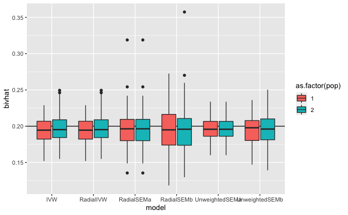

```r
o %>%
  ggplot(., aes(x=model, y=bivhat)) +
  geom_hline(yintercept=0.2) +
  geom_boxplot(aes(fill=as.factor(pop)))
```

Summary:

- Everything works as expected (returning estimates ~ 0.2)
- UnweightedSEMa has better precision because it is jointly estimating biv from two independent datasets - power has improved
- Need to note that unweighted MR / SEM will be unstable if allele frequencies are very small

ToDo:

- Create IVW estimate combining pop1 and pop2 to compare against UnweightedSEMa

## Try different gx

```r
o2 <- pblapply(1:100, function(i)
{
  sim1(
    nsnp=100,
    nid1x=10000,
    nid2x=10000,
    nid1y=10000,
    nid2y=10000,
    h2=0.3,
    S=0,
    biv1=0.2,
    biv2=0.2,
    pl1=0,
    pl2=0,
    absx=FALSE,
    gx_same=FALSE
  ) %>%
    {.$res} %>%
    mutate(sim=i)
}) %>% bind_rows()
```

```
  |                                                  | 0 % ~calculating
  |+                                                 | 1 % ~41s
  |+                                                 | 2 % ~36s
  |++                                                | 3 % ~39s
  |++                                                | 4 % ~42s
  |+++                                               | 5 % ~43s
  |+++                                               | 6 % ~41s
  |++++                                              | 7 % ~41s
  |++++                                              | 8 % ~39s
  |+++++                                             | 9 % ~37s
  |+++++                                             | 10% ~37s
  |++++++                                            | 11% ~39s
  |++++++                                            | 12% ~37s
  |+++++++                                           | 13% ~36s
  |+++++++                                           | 14% ~35s
  |++++++++                                          | 15% ~34s
  |++++++++                                          | 16% ~33s
  |+++++++++                                         | 17% ~32s
  |+++++++++                                         | 18% ~31s
  |++++++++++                                        | 19% ~30s
  |++++++++++                                        | 20% ~29s
  |+++++++++++                                       | 21% ~29s
  |+++++++++++                                       | 22% ~28s
  |++++++++++++                                      | 23% ~27s
  |++++++++++++                                      | 24% ~27s
  |+++++++++++++                                     | 25% ~26s
  |+++++++++++++                                     | 26% ~26s
  |++++++++++++++                                    | 27% ~25s
  |++++++++++++++                                    | 28% ~25s
  |+++++++++++++++                                   | 29% ~24s
  |+++++++++++++++                                   | 30% ~24s
  |++++++++++++++++                                  | 31% ~23s
  |++++++++++++++++                                  | 32% ~23s
  |+++++++++++++++++                                 | 33% ~23s
  |+++++++++++++++++                                 | 34% ~23s
  |++++++++++++++++++                                | 35% ~22s
  |++++++++++++++++++                                | 36% ~22s
  |+++++++++++++++++++                               | 37% ~22s
  |+++++++++++++++++++                               | 38% ~21s
  |++++++++++++++++++++                              | 39% ~21s
```

[output cut: 46 more lines]

```
  |+++++++++++++++++++++++++++++++++++++++++++       | 86% ~05s
  |++++++++++++++++++++++++++++++++++++++++++++      | 87% ~04s
  |++++++++++++++++++++++++++++++++++++++++++++      | 88% ~04s
  |+++++++++++++++++++++++++++++++++++++++++++++     | 89% ~04s
  |+++++++++++++++++++++++++++++++++++++++++++++     | 90% ~03s
  |++++++++++++++++++++++++++++++++++++++++++++++    | 91% ~03s
  |++++++++++++++++++++++++++++++++++++++++++++++    | 92% ~03s
  |+++++++++++++++++++++++++++++++++++++++++++++++   | 93% ~02s
  |+++++++++++++++++++++++++++++++++++++++++++++++   | 94% ~02s
  |++++++++++++++++++++++++++++++++++++++++++++++++  | 95% ~02s
  |++++++++++++++++++++++++++++++++++++++++++++++++  | 96% ~01s
  |+++++++++++++++++++++++++++++++++++++++++++++++++ | 97% ~01s
  |+++++++++++++++++++++++++++++++++++++++++++++++++ | 98% ~01s
  |++++++++++++++++++++++++++++++++++++++++++++++++++| 99% ~00s
  |++++++++++++++++++++++++++++++++++++++++++++++++++| 100% elapsed=33s
```

```r
o2 %>%
  group_by(model, pop) %>%
  summarise(bivhat=mean(bivhat), se=mean(se))
```

| model | pop | bivhat | se |
| --- | --- | --- | --- |
| IVW | 1 | 0.1962653 | 0.01867613 |
| IVW | 2 | 0.1974726 | 0.01865321 |
| RadialIVW | 1 | 0.1962653 | 0.01834259 |
| RadialIVW | 2 | 0.1974726 | 0.01834713 |
| RadialSEMa | 1 | 0.1968098 | 0.02078833 |
| RadialSEMa | 2 | 0.1968098 | 0.02078833 |
| RadialSEMb | 1 | 0.1953003 | 0.02956659 |
| RadialSEMb | 2 | 0.1973332 | 0.02941993 |
| UnweightedSEMa | 1 | 0.1961207 | 0.01391665 |
| UnweightedSEMa | 2 | 0.1961207 | 0.01391665 |

[output cut: 2 more lines]

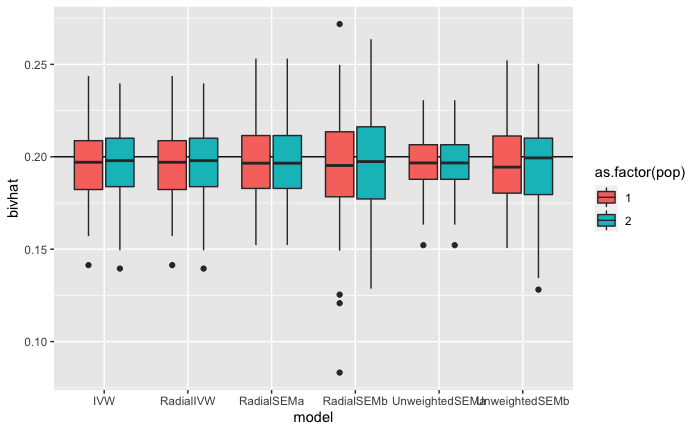

```r
o2 %>%
  ggplot(., aes(x=model, y=bivhat)) +
  geom_hline(yintercept=0.2) +
  geom_boxplot(aes(fill=as.factor(pop)))
```

## Instrument significance

```r
o31 <- pblapply(1:100, function(i)
{
  sim1(
    nsnp=100,
    nid1x=10000,
    nid2x=10000,
    nid1y=10000,
    nid2y=10000,
    h2=0.3,
    S=0,
    biv1=0.2,
    biv2=0.2,
    pl1=0,
    pl2=0,
    absx=FALSE,
    gx_same=FALSE,
    instrument_threshold = 5e-8,
    winnerscurse_adjustment = TRUE
  ) %>%
    {.$res} %>%
    mutate(sim=i, wc=TRUE)
}) %>% bind_rows()
```

```
  |                                                  | 0 % ~calculating
  |+                                                 | 1 % ~53s
  |+                                                 | 2 % ~46s
  |++                                                | 3 % ~46s
  |++                                                | 4 % ~51s
  |+++                                               | 5 % ~57s
  |+++                                               | 6 % ~01m 01s
  |++++                                              | 7 % ~60s
  |++++                                              | 8 % ~59s
  |+++++                                             | 9 % ~56s
  |+++++                                             | 10% ~53s
  |++++++                                            | 11% ~52s
  |++++++                                            | 12% ~50s
  |+++++++                                           | 13% ~47s
  |+++++++                                           | 14% ~45s
  |++++++++                                          | 15% ~44s
  |++++++++                                          | 16% ~42s
  |+++++++++                                         | 17% ~41s
  |+++++++++                                         | 18% ~40s
  |++++++++++                                        | 19% ~39s
  |++++++++++                                        | 20% ~38s
  |+++++++++++                                       | 21% ~37s
  |+++++++++++                                       | 22% ~36s
  |++++++++++++                                      | 23% ~35s
  |++++++++++++                                      | 24% ~35s
  |+++++++++++++                                     | 25% ~34s
  |+++++++++++++                                     | 26% ~33s
  |++++++++++++++                                    | 27% ~32s
  |++++++++++++++                                    | 28% ~32s
  |+++++++++++++++                                   | 29% ~32s
  |+++++++++++++++                                   | 30% ~31s
  |++++++++++++++++                                  | 31% ~30s
  |++++++++++++++++                                  | 32% ~30s
  |+++++++++++++++++                                 | 33% ~29s
  |+++++++++++++++++                                 | 34% ~28s
  |++++++++++++++++++                                | 35% ~28s
  |++++++++++++++++++                                | 36% ~27s
  |+++++++++++++++++++                               | 37% ~26s
  |+++++++++++++++++++                               | 38% ~26s
  |++++++++++++++++++++                              | 39% ~25s
```

[output cut: 46 more lines]

```
  |+++++++++++++++++++++++++++++++++++++++++++       | 86% ~05s
  |++++++++++++++++++++++++++++++++++++++++++++      | 87% ~05s
  |++++++++++++++++++++++++++++++++++++++++++++      | 88% ~04s
  |+++++++++++++++++++++++++++++++++++++++++++++     | 89% ~04s
  |+++++++++++++++++++++++++++++++++++++++++++++     | 90% ~04s
  |++++++++++++++++++++++++++++++++++++++++++++++    | 91% ~03s
  |++++++++++++++++++++++++++++++++++++++++++++++    | 92% ~03s
  |+++++++++++++++++++++++++++++++++++++++++++++++   | 93% ~03s
  |+++++++++++++++++++++++++++++++++++++++++++++++   | 94% ~02s
  |++++++++++++++++++++++++++++++++++++++++++++++++  | 95% ~02s
  |++++++++++++++++++++++++++++++++++++++++++++++++  | 96% ~01s
  |+++++++++++++++++++++++++++++++++++++++++++++++++ | 97% ~01s
  |+++++++++++++++++++++++++++++++++++++++++++++++++ | 98% ~01s
  |++++++++++++++++++++++++++++++++++++++++++++++++++| 99% ~00s
  |++++++++++++++++++++++++++++++++++++++++++++++++++| 100% elapsed=36s
```

```r
o32 <- pblapply(1:100, function(i)
{
  sim1(
    nsnp=100,
    nid1x=10000,
    nid2x=10000,
    nid1y=10000,
    nid2y=10000,
    h2=0.3,
    S=0,
    biv1=0.2,
    biv2=0.2,
    pl1=0,
    pl2=0,
    absx=FALSE,
    gx_same=FALSE,
    instrument_threshold = 5e-8,
    winnerscurse_adjustment = FALSE
  ) %>%
    {.$res} %>%
    mutate(sim=i, wc=FALSE)
}) %>% bind_rows()
```

```
  |                                                  | 0 % ~calculating
  |+                                                 | 1 % ~40s
  |+                                                 | 2 % ~38s
  |++                                                | 3 % ~35s
  |++                                                | 4 % ~37s
  |+++                                               | 5 % ~37s
  |+++                                               | 6 % ~35s
  |++++                                              | 7 % ~35s
  |++++                                              | 8 % ~34s
  |+++++                                             | 9 % ~34s
  |+++++                                             | 10% ~39s
  |++++++                                            | 11% ~39s
  |++++++                                            | 12% ~38s
  |+++++++                                           | 13% ~37s
  |+++++++                                           | 14% ~36s
  |++++++++                                          | 15% ~35s
  |++++++++                                          | 16% ~33s
  |+++++++++                                         | 17% ~33s
  |+++++++++                                         | 18% ~33s
  |++++++++++                                        | 19% ~32s
  |++++++++++                                        | 20% ~31s
  |+++++++++++                                       | 21% ~31s
  |+++++++++++                                       | 22% ~30s
  |++++++++++++                                      | 23% ~29s
  |++++++++++++                                      | 24% ~29s
  |+++++++++++++                                     | 25% ~28s
  |+++++++++++++                                     | 26% ~28s
  |++++++++++++++                                    | 27% ~27s
  |++++++++++++++                                    | 28% ~26s
  |+++++++++++++++                                   | 29% ~26s
  |+++++++++++++++                                   | 30% ~25s
  |++++++++++++++++                                  | 31% ~25s
  |++++++++++++++++                                  | 32% ~24s
  |+++++++++++++++++                                 | 33% ~24s
  |+++++++++++++++++                                 | 34% ~23s
  |++++++++++++++++++                                | 35% ~23s
  |++++++++++++++++++                                | 36% ~23s
  |+++++++++++++++++++                               | 37% ~22s
  |+++++++++++++++++++                               | 38% ~22s
  |++++++++++++++++++++                              | 39% ~21s
```

[output cut: 46 more lines]

```
  |+++++++++++++++++++++++++++++++++++++++++++       | 86% ~07s
  |++++++++++++++++++++++++++++++++++++++++++++      | 87% ~06s
  |++++++++++++++++++++++++++++++++++++++++++++      | 88% ~06s
  |+++++++++++++++++++++++++++++++++++++++++++++     | 89% ~05s
  |+++++++++++++++++++++++++++++++++++++++++++++     | 90% ~05s
  |++++++++++++++++++++++++++++++++++++++++++++++    | 91% ~04s
  |++++++++++++++++++++++++++++++++++++++++++++++    | 92% ~04s
  |+++++++++++++++++++++++++++++++++++++++++++++++   | 93% ~03s
  |+++++++++++++++++++++++++++++++++++++++++++++++   | 94% ~03s
  |++++++++++++++++++++++++++++++++++++++++++++++++  | 95% ~02s
  |++++++++++++++++++++++++++++++++++++++++++++++++  | 96% ~02s
  |+++++++++++++++++++++++++++++++++++++++++++++++++ | 97% ~01s
  |+++++++++++++++++++++++++++++++++++++++++++++++++ | 98% ~01s
  |++++++++++++++++++++++++++++++++++++++++++++++++++| 99% ~00s
  |++++++++++++++++++++++++++++++++++++++++++++++++++| 100% elapsed=49s
```

```r
o3 <- rbind(o31, o32)
o3 %>%
  group_by(model, pop, wc) %>%
  summarise(bivhat=mean(bivhat), se=mean(se))
```

| model | pop | wc | bivhat | se |
| --- | --- | --- | --- | --- |
| IVW | 1 | FALSE | 0.1911034 | 0.02007387 |
| IVW | 1 | TRUE | 0.1991721 | 0.02052308 |
| IVW | 2 | FALSE | 0.1940919 | 0.02022492 |
| IVW | 2 | TRUE | 0.1987058 | 0.02051082 |
| RadialIVW | 1 | FALSE | 0.1911034 | 0.01953247 |
| RadialIVW | 1 | TRUE | 0.1991721 | 0.01988941 |
| RadialIVW | 2 | FALSE | 0.1940919 | 0.01953117 |
| RadialIVW | 2 | TRUE | 0.1987058 | 0.01985410 |
| RadialSEMa | 1 | FALSE | 0.1964407 | 0.02575572 |
| RadialSEMa | 1 | TRUE | 0.1954389 | 0.02552558 |

[output cut: 14 more lines]

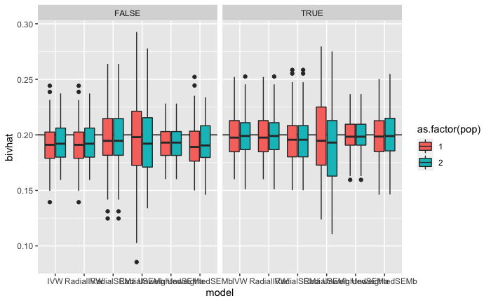

```r
o3 %>%
  ggplot(., aes(x=model, y=bivhat)) +
  geom_hline(yintercept=0.2) +
  geom_boxplot(aes(fill=as.factor(pop))) +
  facet_grid(. ~ wc)
```

- Winner’s curse seems to be introducing a slight downward bias.

## Introducing pleiotropy

```r
out <- sim1(
  nsnp=100,
  nid1x=10000,
  nid2x=10000,
  nid1y=10000,
  nid2y=10000,
  h2=0.3,
  S=0,
  biv1=0.2,
  biv2=0.2,
  pl1=0.2,
  pl2=0.2,
  absx=TRUE
)
```

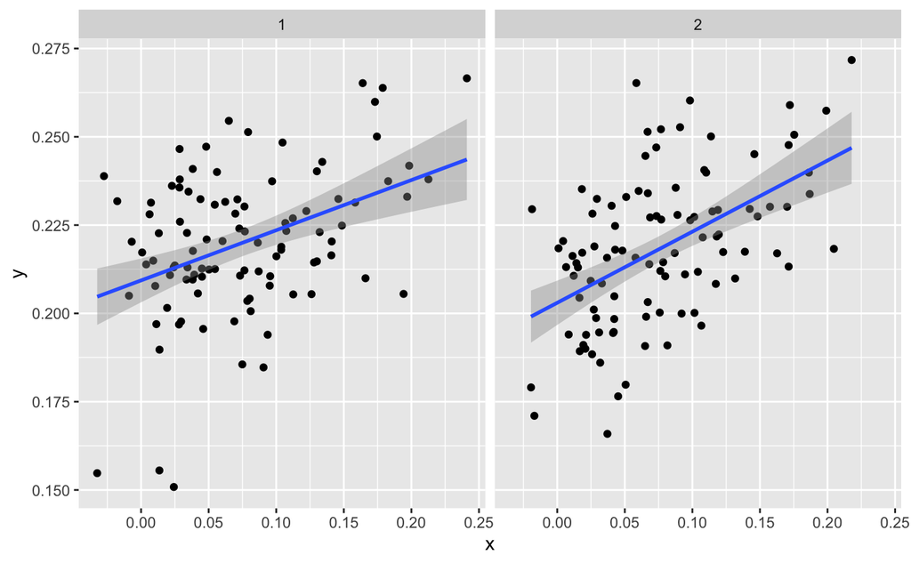

```r
out$dat %>%
  {bind_rows(
    tibble(pop=1, x=.$x1, y=.$y1),
    tibble(pop=2, x=.$x2, y=.$y2)
  )} %>%
  ggplot(., aes(x=x, y=y)) +
    geom_point() +
    geom_smooth(method=lm) +
    facet_grid(. ~ pop)
```

Intercept is now through 0.2 instead of 0 - directional pleiotropy

```r
out$res
```

| model | pop | bivhat | se | pval | aic |
| --- | --- | --- | --- | --- | --- |
| IVW | 1 | 1.8549060 | 0.12998649 | 3.366230e-46 | NA |
| IVW | 2 | 1.9051537 | 0.12689598 | 5.989475e-51 | NA |
| RadialIVW | 1 | 1.8549060 | 0.12998649 | 9.238583e-26 | NA |
| RadialIVW | 2 | 1.9051537 | 0.12689598 | 2.919445e-27 | NA |
| UnweightedSEMa | 1 | 0.1723441 | 0.02284689 | 4.574119e-14 | -1014.287 |
| UnweightedSEMa | 2 | 0.1723441 | 0.02284689 | 4.574119e-14 | -1014.287 |
| UnweightedSEMb | 1 | 0.1435630 | 0.03249640 | 9.970507e-06 | -1013.778 |
| UnweightedSEMb | 2 | 0.2019148 | 0.03341979 | 1.524303e-09 | -1013.778 |
| RadialSEMa | 1 | 0.6391331 | 0.10453813 | 9.724037e-10 | 1194.634 |
| RadialSEMa | 2 | 0.6391331 | 0.10453813 | 9.724037e-10 | 1194.634 |

[output cut: 2 more lines]

Somewhat unexpected that unweighted SEM is actually unbiased?!

Run a few more times

```r
op <- pblapply(1:100, function(i)
{
  sim1(
    nsnp=100,
    nid1x=10000,
    nid2x=10000,
    nid1y=10000,
    nid2y=10000,
    h2=0.3,
    S=0,
    biv1=0.2,
    biv2=0.2,
    pl1=0.2,
    pl2=0.2,
    absx=TRUE
  ) %>%
    {.$res} %>%
    mutate(sim=i)
}) %>% bind_rows()
```

```
  |                                                  | 0 % ~calculating
  |+                                                 | 1 % ~36s
  |+                                                 | 2 % ~42s
  |++                                                | 3 % ~47s
  |++                                                | 4 % ~45s
  |+++                                               | 5 % ~42s
  |+++                                               | 6 % ~39s
  |++++                                              | 7 % ~38s
  |++++                                              | 8 % ~42s
  |+++++                                             | 9 % ~42s
  |+++++                                             | 10% ~42s
  |++++++                                            | 11% ~40s
  |++++++                                            | 12% ~39s
  |+++++++                                           | 13% ~37s
  |+++++++                                           | 14% ~36s
  |++++++++                                          | 15% ~35s
  |++++++++                                          | 16% ~35s
  |+++++++++                                         | 17% ~34s
  |+++++++++                                         | 18% ~34s
  |++++++++++                                        | 19% ~33s
  |++++++++++                                        | 20% ~33s
  |+++++++++++                                       | 21% ~33s
  |+++++++++++                                       | 22% ~33s
  |++++++++++++                                      | 23% ~33s
  |++++++++++++                                      | 24% ~33s
  |+++++++++++++                                     | 25% ~32s
  |+++++++++++++                                     | 26% ~32s
  |++++++++++++++                                    | 27% ~31s
  |++++++++++++++                                    | 28% ~30s
  |+++++++++++++++                                   | 29% ~30s
  |+++++++++++++++                                   | 30% ~30s
  |++++++++++++++++                                  | 31% ~29s
  |++++++++++++++++                                  | 32% ~29s
  |+++++++++++++++++                                 | 33% ~29s
  |+++++++++++++++++                                 | 34% ~28s
  |++++++++++++++++++                                | 35% ~27s
  |++++++++++++++++++                                | 36% ~27s
  |+++++++++++++++++++                               | 37% ~26s
  |+++++++++++++++++++                               | 38% ~26s
  |++++++++++++++++++++                              | 39% ~26s
```

[output cut: 46 more lines]

```
  |+++++++++++++++++++++++++++++++++++++++++++       | 86% ~06s
  |++++++++++++++++++++++++++++++++++++++++++++      | 87% ~06s
  |++++++++++++++++++++++++++++++++++++++++++++      | 88% ~05s
  |+++++++++++++++++++++++++++++++++++++++++++++     | 89% ~05s
  |+++++++++++++++++++++++++++++++++++++++++++++     | 90% ~04s
  |++++++++++++++++++++++++++++++++++++++++++++++    | 91% ~04s
  |++++++++++++++++++++++++++++++++++++++++++++++    | 92% ~03s
  |+++++++++++++++++++++++++++++++++++++++++++++++   | 93% ~03s
  |+++++++++++++++++++++++++++++++++++++++++++++++   | 94% ~03s
  |++++++++++++++++++++++++++++++++++++++++++++++++  | 95% ~02s
  |++++++++++++++++++++++++++++++++++++++++++++++++  | 96% ~02s
  |+++++++++++++++++++++++++++++++++++++++++++++++++ | 97% ~01s
  |+++++++++++++++++++++++++++++++++++++++++++++++++ | 98% ~01s
  |++++++++++++++++++++++++++++++++++++++++++++++++++| 99% ~00s
  |++++++++++++++++++++++++++++++++++++++++++++++++++| 100% elapsed=43s
```

```r
op %>%
  group_by(model, pop) %>%
  summarise(bivhat=mean(bivhat), se=mean(se))
```

| model | pop | bivhat | se |
| --- | --- | --- | --- |
| IVW | 1 | 1.9023899 | 0.13563888 |
| IVW | 2 | 1.9039056 | 0.13545740 |
| RadialIVW | 1 | 1.9023899 | 0.13563888 |
| RadialIVW | 2 | 1.9039056 | 0.13545740 |
| RadialSEMa | 1 | 0.7993623 | 0.12326082 |
| RadialSEMa | 2 | 0.7993623 | 0.12326082 |
| RadialSEMb | 1 | 0.8183963 | 0.16609384 |
| RadialSEMb | 2 | 0.8171152 | 0.16682589 |
| UnweightedSEMa | 1 | 0.1745999 | 0.02236170 |
| UnweightedSEMa | 2 | 0.1745999 | 0.02236170 |

[output cut: 2 more lines]

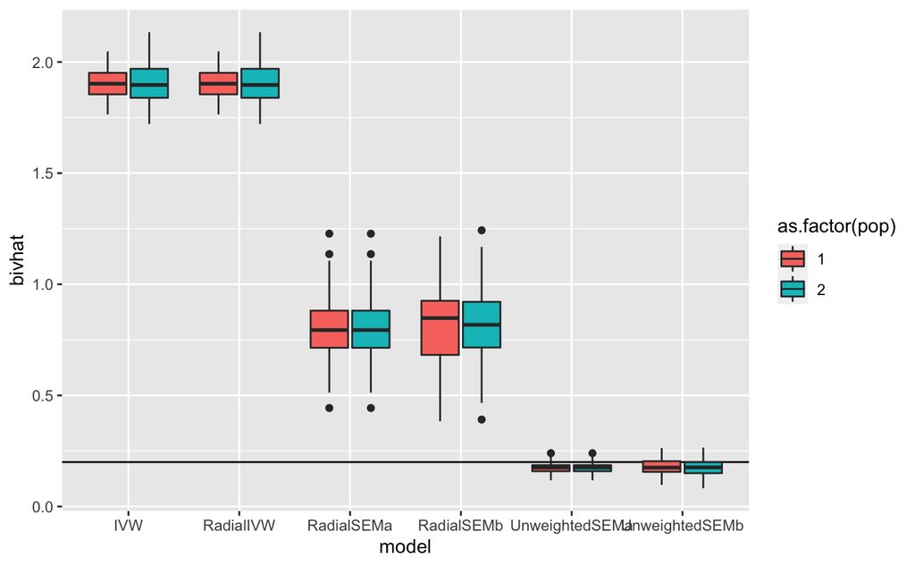

```r
op %>%
  ggplot(., aes(x=model, y=bivhat)) +
  geom_hline(yintercept=0.2) +
  geom_boxplot(aes(fill=as.factor(pop)))
```

Summary

- The unweightedSEM method handles directional pleiotropy automatically

## Population-specific effects

```r
od <- pblapply(1:500, function(i)
{
  biv1=sample(c(0, rnorm(1, sd=0.01)), 1)
  biv2=sample(c(0, rnorm(1, sd=0.01)), 1)
  sim1(
    nsnp=100,
    nid1x=10000,
    nid2x=10000,
    nid1y=10000,
    nid2y=10000,
    h2=0.3,
    S=0,
    biv1=biv1,
    biv2=biv2,
    pl1=0,
    pl2=0,
    absx=FALSE
  ) %>%
    {.$popdiff} %>%
    mutate(sim=i, biv1=biv1, biv2=biv2)
}) %>% bind_rows()
```

```
  |                                                  | 0 % ~calculating
  |+                                                 | 1 % ~03m 25s
  |+                                                 | 2 % ~03m 43s
  |++                                                | 3 % ~03m 57s
  |++                                                | 4 % ~03m 36s
  |+++                                               | 5 % ~03m 31s
  |+++                                               | 6 % ~03m 27s
  |++++                                              | 7 % ~03m 15s
  |++++                                              | 8 % ~03m 17s
  |+++++                                             | 9 % ~03m 23s
  |+++++                                             | 10% ~03m 19s
  |++++++                                            | 11% ~03m 17s
  |++++++                                            | 12% ~03m 17s
  |+++++++                                           | 13% ~03m 12s
  |+++++++                                           | 14% ~03m 08s
  |++++++++                                          | 15% ~03m 05s
  |++++++++                                          | 16% ~03m 01s
  |+++++++++                                         | 17% ~02m 58s
  |+++++++++                                         | 18% ~02m 53s
  |++++++++++                                        | 19% ~02m 49s
  |++++++++++                                        | 20% ~02m 47s
  |+++++++++++                                       | 21% ~02m 44s
  |+++++++++++                                       | 22% ~02m 43s
  |++++++++++++                                      | 23% ~02m 42s
  |++++++++++++                                      | 24% ~02m 48s
  |+++++++++++++                                     | 25% ~02m 49s
  |+++++++++++++                                     | 26% ~02m 45s
  |++++++++++++++                                    | 27% ~02m 41s
  |++++++++++++++                                    | 28% ~02m 38s
  |+++++++++++++++                                   | 29% ~02m 34s
  |+++++++++++++++                                   | 30% ~02m 30s
  |++++++++++++++++                                  | 31% ~02m 26s
  |++++++++++++++++                                  | 32% ~02m 22s
  |+++++++++++++++++                                 | 33% ~02m 19s
  |+++++++++++++++++                                 | 34% ~02m 15s
  |++++++++++++++++++                                | 35% ~02m 12s
  |++++++++++++++++++                                | 36% ~02m 09s
  |+++++++++++++++++++                               | 37% ~02m 06s
  |+++++++++++++++++++                               | 38% ~02m 02s
  |++++++++++++++++++++                              | 39% ~01m 59s
```

[output cut: 46 more lines]

```
  |+++++++++++++++++++++++++++++++++++++++++++       | 86% ~26s
  |++++++++++++++++++++++++++++++++++++++++++++      | 87% ~24s
  |++++++++++++++++++++++++++++++++++++++++++++      | 88% ~22s
  |+++++++++++++++++++++++++++++++++++++++++++++     | 89% ~20s
  |+++++++++++++++++++++++++++++++++++++++++++++     | 90% ~18s
  |++++++++++++++++++++++++++++++++++++++++++++++    | 91% ~16s
  |++++++++++++++++++++++++++++++++++++++++++++++    | 92% ~15s
  |+++++++++++++++++++++++++++++++++++++++++++++++   | 93% ~13s
  |+++++++++++++++++++++++++++++++++++++++++++++++   | 94% ~11s
  |++++++++++++++++++++++++++++++++++++++++++++++++  | 95% ~09s
  |++++++++++++++++++++++++++++++++++++++++++++++++  | 96% ~07s
  |+++++++++++++++++++++++++++++++++++++++++++++++++ | 97% ~05s
  |+++++++++++++++++++++++++++++++++++++++++++++++++ | 98% ~04s
  |++++++++++++++++++++++++++++++++++++++++++++++++++| 99% ~02s
  |++++++++++++++++++++++++++++++++++++++++++++++++++| 100% elapsed=03m 02s
```

How well does the difference statistic for each method discriminate between cases where the causal effects are the same or different?

```r
od %>%
  mutate(same=as.numeric(biv1==biv2)) %>%
  group_by(model) %>%
  summarise(o=as.numeric(auc(response=same, predictor=stat)))
```

| model | o |
| --- | --- |
| IVW | 0.4778451 |
| RadialIVW | 0.4790695 |
| RadialSEM | 0.5058580 |
| UnweightedSEM | 0.5307889 |

Comparison across methods

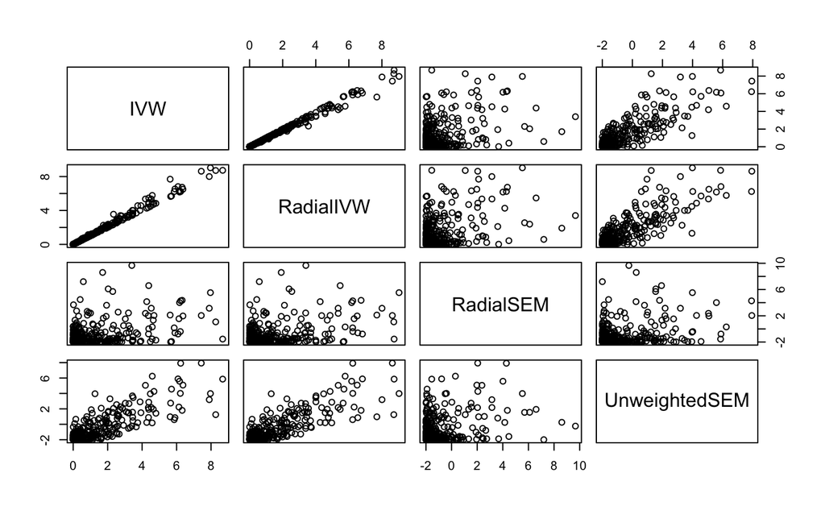

```r
od %>%
  subset(., biv1 != biv2) %>%
  dplyr::select(model, stat, sim) %>%
  pivot_wider(id_cols=c(sim, model), names_from=model, values_from=stat) %>%
  select(-sim) %>%
  pairs()
```

Comparison by effect size difference

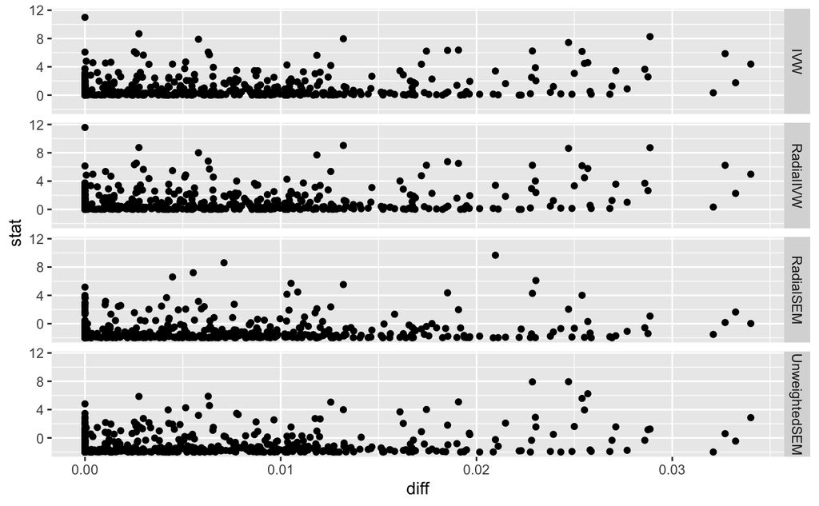

```r
od %>%
  mutate(diff=abs(biv1-biv2)) %>%
  ggplot(., aes(x=diff, y=stat)) +
    geom_point() +
    facet_grid(model ~ .)
```

Use p-value of 0.05 for Q stat to declare significantly different. What should be used for AIC?

```r
aic_thresh <- od %>%
  subset(., biv1==biv2 & model == "UnweightedSEM") %>%
  summarise(t=quantile(stat, 0.95)) %>%
  {.$t}
aic_thresh
```

```
     95%
1.736814
```

```r
od <- od %>%
  mutate(same=biv1==biv2, sig=case_when(
    model %in% c("IVW", "RadialIVW") ~ pchisq(stat, df=1, low=FALSE) < 0.05,
    model %in% c("UnweightedSEM", "RadialSEM") ~ stat > aic_thresh
  ))


od %>%
  filter(same) %>%
  group_by(model) %>%
  summarise(fdr=sum(sig)/n())
```

| model | fdr |
| --- | --- |
| IVW | 0.01574803 |
| RadialIVW | 0.01574803 |
| RadialSEM | 0.06299213 |
| UnweightedSEM | 0.05511811 |

```r
od %>%
  filter(!same) %>%
  group_by(model) %>%
  summarise(power=sum(sig)/n())
```

| model | power |
| --- | --- |
| IVW | 0.08579088 |
| RadialIVW | 0.09383378 |
| RadialSEM | 0.08310992 |
| UnweightedSEM | 0.09651475 |

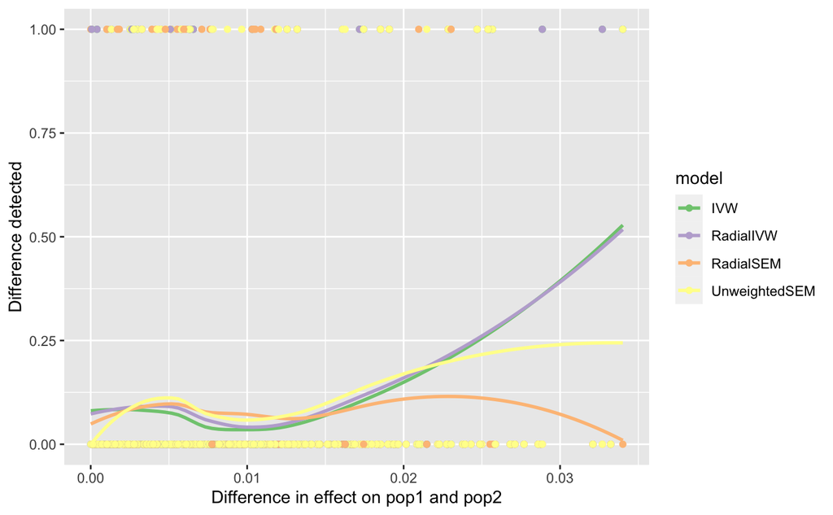

```r
od %>%
  filter(biv1 != biv2) %>%
  ggplot(., aes(x=abs(biv1-biv2), y=as.numeric(sig))) +
  geom_point(aes(colour=model)) +
  geom_smooth(aes(colour=model), se=FALSE) +
  scale_colour_brewer(type="qual") +
  labs(x="Difference in effect on pop1 and pop2", y="Difference detected")
```

Summary

- The UnweightedSEM method, IVW and RadialIVW methods seem to perform comparably

Todo:

- Power of test statistic when effect sizes are different
- Power to detect when SNP-exposure effects are different
- LD-aware simulations: how well can we discriminate between distinct causal variants vs false negatives due to power?

# Older stuff

## Further analysis of population specific estimates

```r
param <- expand.grid(

)
```

```r
effects1 <- effects2 <- choose_effects(200, 0.4)
effects1[1:50] <- 0
effects2[51:100] <- 0

# create genotypes
g1 <- make_geno(10000, 200, 0.5)
g2 <- make_geno(10000, 200, 0.5)

# create confounder
u1 <- rnorm(10000)
u2 <- rnorm(10000)

# create x
x1 <- make_phen(c(0.1, effects1), cbind(u1, g1))
x2 <- make_phen(c(0.1, effects2), cbind(u2, g2))

plei <- choose_effects(200, 0.4)

# create y
y1 <- make_phen(c(0.1, 0.2, plei), cbind(u1, x1, g1))
y2 <- make_phen(c(0.1, 0.2, plei), cbind(u2, x2, g2))

# Summary data for pop1
ss1 <- get_effs(x1, y1, g1)

# Summary data for pop2
ss2 <- get_effs(x2, y2, g2)

mres1 <- mr(ss1, method="mr_ivw")
```

```
Analysing 'X' on 'Y'
```

```r
mres2 <- mr(ss2, method="mr_ivw")
```

```
Analysing 'X' on 'Y'
```

```r
plot(beta.outcome ~ beta.exposure, ss1)
abline(a=0, b=1)
```

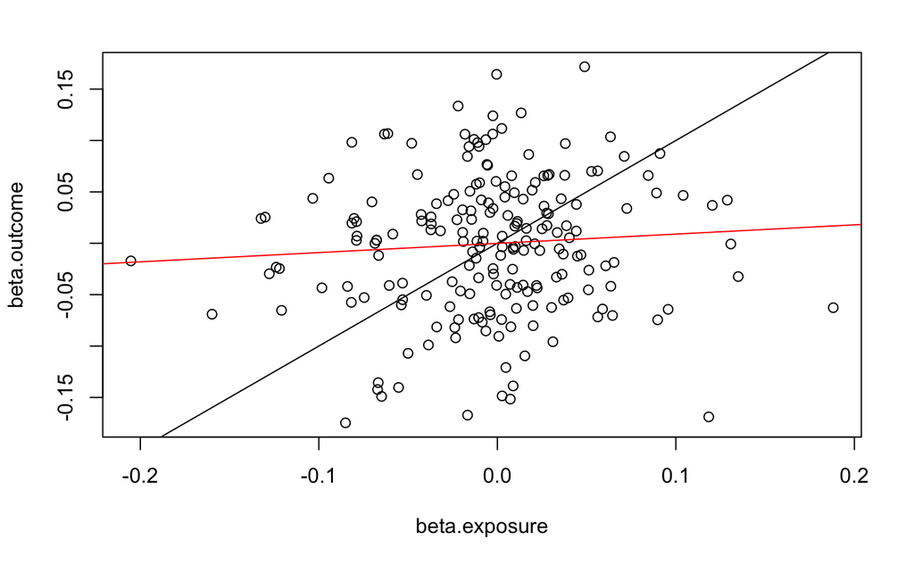

```r
abline(a=0, b=mres1$b, col="red")
```

```r
# Organise the data
dat <- tibble(
    y1 = ss1$beta.outcome,
    y2 = ss2$beta.outcome,
    x1 = ss1$beta.exposure,
    x2 = ss2$beta.exposure
)

dat$xb <- rowMeans(cbind(dat$x1, dat$x2))
dat$xb[1:100] <- 0
dat$x1[1:50] <- 0
dat$x1[101:200] <- 0
dat$x2[51:100] <- 0
dat$x2[101:200] <- 0

model <- '
y1 ~ b_1*x1 + b_1*xb + p_1*x2
y2 ~ p_2*x1 + b_2*xb + b_2*x2
x1 ~~ 0 * x2
x1 ~~ 0 * xb
x2 ~~ 0 * xb
'
cor(dat)
```

```
           y1          y2           x1           x2           xb
y1 1.00000000  0.94979815  0.024980191  0.069528151  0.096949958
y2 0.94979815  1.00000000 -0.050495606  0.188861998  0.096958684
x1 0.02498019 -0.05049561  1.000000000  0.001271833  0.002049102
x2 0.06952815  0.18886200  0.001271833  1.000000000 -0.007447125
xb 0.09694996  0.09695868  0.002049102 -0.007447125  1.000000000
```

```r
mod <- sem(model, data=dat)
summary(mod)
```

```
lavaan 0.6-8 ended normally after 86 iterations

  Estimator                                         ML
  Optimization method                           NLMINB
  Number of model parameters                        12
  Number of equality constraints                     2

  Number of observations                           200

Model Test User Model:

  Test statistic                                 2.475
  Degrees of freedom                                 5
  P-value (Chi-square)                           0.780

Parameter Estimates:

  Standard errors                             Standard
  Information                                 Expected
  Information saturated (h1) model          Structured

Regressions:
                   Estimate  Std.Err  z-value  P(>|z|)
  y1 ~
    x1       (b_1)    0.186    0.074    2.518    0.012
    xb       (b_1)    0.186    0.074    2.518    0.012
    x2       (p_1)   -0.030    0.080   -0.374    0.708
  y2 ~
    x1       (p_2)   -0.007    0.083   -0.089    0.929
    xb       (b_2)    0.187    0.070    2.668    0.008
    x2       (b_2)    0.187    0.070    2.668    0.008

Covariances:
                   Estimate  Std.Err  z-value  P(>|z|)
  x1 ~~
    x2                0.000
    xb                0.000
  xb ~~
    x2                0.000
 .y1 ~~
   .y2                0.004    0.000    9.789    0.000

Variances:
                   Estimate  Std.Err  z-value  P(>|z|)
   .y1                0.004    0.000   10.000    0.000
   .y2                0.004    0.000   10.000    0.000
    x1                0.001    0.000   10.000    0.000
    xb                0.002    0.000   10.000    0.000
    x2                0.001    0.000   10.000    0.000
```

```r
semPaths(mod, edge.label.cex = 0.7, edge.label.position=0.7)
```

[output not shown]

```r
nsnp <- 200
map <- tibble(
    snp=1:200,
    af=0.5
) %>%
    mutate(beta =
        case_when(
            snp >
    ))


xp <- generate_gwas_params(map, 0.4)

x1p <- xp %>%
    mutate(beta =
        case_when(
            snp <= 50 ~ 0,
            TRUE ~ beta
        )
    )

y1p <- x1p %>%
    mutate(beta = beta * 0.2 + 0.1)

x2p <- xp %>%
    mutate(beta =
        case_when(
            snp > 50 & snp <= 100 ~ 0,
            TRUE ~ beta
        )
    )

y2p <- x2p %>%
    mutate(beta = beta * 0.2 + 0.1)

yp <- xp %>%
    mutate(beta = beta * 0.2)

summary(lm(yp$beta ~ -1 + xp$beta))
summary(lm(y1p$beta ~ -1 + x1p$beta))
summary(lm(y2p$beta ~ -1 + x2p$beta))

y1 <- generate_gwas_ss(y1p, 1000000)
y2 <- generate_gwas_ss(y2p, 1000000)
x1 <- generate_gwas_ss(x1p, 1000000)
x2 <- generate_gwas_ss(x2p, 1000000)

dat <- tibble(
    y1 = y1$bhat,
    y2 = y2$bhat,
    x1 = x1$bhat,
    x2 = x2$bhat
)

dat$xb <- rowMeans(cbind(dat$x1, dat$x2))
dat$xb[1:100] <- 0
dat$x1[1:50] <- 0
dat$x1[101:200] <- 0
dat$x2[51:100] <- 0
dat$x2[101:200] <- 0

summary(lm(cbind(y1, y2) ~ -1 + x1 + x2 + xb, dat))


summary(lm(y1$bhat ~ -1 + x1$bhat))


model <- '
# linear model
y1 ~ b11*x1 + b11*xb + p1*x2
y2 ~ p2*x1 + b22*xb + b22*x2
'

mod <- sem(model, data=dat, meanstructure=FALSE)
summary(mod)


model <- '
# linear model
y1 ~ b11*x1 + b11*xb + p1*x2
y2 ~ p2*x1 + b22*xb + b22*x2
'

mod <- sem(model, data=dat, meanstructure=FALSE)
summary(mod)


dat2 <- tibble(
    w1 = abs(x1$bhat) / y1$se,
    w2 = abs(x2$bhat) / y2$se,
    Y1 = y1$bhat / x1$bhat * w1,
    Y2 = y2$bhat / x2$bhat * w2,
)

summary(lm(Y1 ~ -1 + w1, dat2))
summary(lm(y1$bhat ~ -1 + x1$bhat, weight=1/y1$se^2))





model <- '
y1 ~ xb + x1
'
summary(sem(model, data=dat))



up <- map %>%
    generate_gwas_params(., 0.1)

xp <- up %>%
    mutate(beta=beta * 0.2)

yp <- up %>%
    mutate(beta=beta * 0.4 + beta * 0.3)

x1p <- xp %>%
    mutate(beta =
        case_when(
            snp <= 50 ~ 0,
            TRUE ~ beta
        )
    )

y1p <- x1p %>%
    mutate(beta = case_when(
        beta == 0 ~ beta * 0.4,
        TRUE ~ beta * 0.4 + beta * 0.3
    ))

x2p <- xp %>%
    mutate(beta =
        case_when(
            snp > 50 & snp <= 100 ~ 0,
            TRUE ~ beta
        )
    )

y2p <- x2p %>%
    mutate(beta = case_when(
        beta == 0 ~ beta * 0.4,
        TRUE ~ beta * 0.4 + beta * 0.3
    ))

plot(y1p$beta ~ x1p$beta)

summary(lm(yp$beta ~ xp$beta))

summary(lm(y2p$beta ~ x1p$beta, subset=x1p$beta == 0))



####


# create genotypes
g1 <- make_geno(10000, 200, 0.5)
g2 <- make_geno(10000, 200, 0.5)

# create confounder
plei1 <- plei2 <- choose_effects(200, 0.4)
effects1[1:50] <- 0
effects2[51:100] <- 0
u1 <- make_phen(plei, g1)
u2 <- make_phen(plei, g2)

x1 <- make_phen(0.6, u1)
x2 <- make_phen(0.6, u2)

y1 <- make_phen(c(0.6, -0.4), cbind(u1, x1))
y2 <- make_phen(c(0.6, -0.4), cbind(u2, x2))


# Summary data for pop1
ss1 <- get_effs(x1, y1, g1)

# Summary data for pop2
ss2 <- get_effs(x2, y2, g2)

(mres1 <- mr(ss1, method="mr_ivw"))
(mres2 <- mr(ss2, method="mr_ivw"))


plot(beta.outcome ~ beta.exposure, ss1)
abline(a=0, b=1)
abline(a=0, b=mres1$b, col="red")

# Organise the data
dat <- tibble(
    y1 = ss1$beta.outcome,
    y2 = ss2$beta.outcome,
    x1 = ss1$beta.exposure,
    x2 = ss2$beta.exposure
)

dat$xb <- rowMeans(cbind(dat$x1, dat$x2))
dat$xb[1:100] <- 0
dat$x1[1:50] <- 0
dat$x1[101:200] <- 0
dat$x2[51:100] <- 0
dat$x2[101:200] <- 0


model <- '
y1 ~ b_1*x1 + b_1*xb + p_1*x2
y2 ~ p_2*x1 + b_2*xb + b_2*x2
'

mod <- sem(model, data=dat)
summary(mod)


########

# try again


# create genotypes
g1 <- make_geno(10000, 50, 0.5)
g2 <- make_geno(10000, 50, 0.5)
gb <- make_geno(10000, 100, 0.5)

eff1 <- choose_effects(50, 0.2)
eff2 <- choose_effects(50, 0.2)
effb <- choose_effects(100, 0.2)
x1 <- make_phen(eff1, g1)
x2 <- make_phen(eff2, g2)
xb <- make_phen(effb, gb)

plei1 <- choose_effects(50, 0.1)
plei2 <- choose_effects(50, 0.1)
y1 <- make_phen(c(eff1, eff2, effb, 0.2, 0.2), cbind(g1, g2, gb, x1, xb))
y2 <- make_phen(c(eff1, eff2, effb, 0.2, 0.2), cbind(g1, g2, gb, x2, xb))




# Summary data for pop1
ss1 <- get_effs(x1, y1, g1)

# Summary data for pop2
ss2 <- get_effs(x2, y2, g2) %>% mutate(SNP = SNP + 50)

ssb1 <- get_effs(xb, y1, gb) %>% mutate(SNP = SNP + 100)
ssb2 <- get_effs(xb, y2, gb) %>% mutate(SNP = SNP + 100)


mres1 <- mr(ss1, method="mr_ivw")
mres2 <- mr(ss2, method="mr_ivw")


plot(beta.outcome ~ beta.exposure, ss1)
abline(a=0, b=1)
abline(a=0, b=mres1$b, col="red")

# Organise the data
dat <- tibble(
    y1 = ss1$beta.outcome,
    y2 = ss2$beta.outcome,
    x1 = ss1$beta.exposure,
    x2 = ss2$beta.exposure
)

dat$xb <- rowMeans(cbind(dat$x1, dat$x2))
dat$xb[1:100] <- 0
dat$x1[1:50] <- 0
dat$x1[101:200] <- 0
dat$x2[51:100] <- 0
dat$x2[101:200] <- 0





model <- '
y1 ~ b_1*x1 + b_1*xb + p_1*x2
y2 ~ p_2*x1 + b_2*xb + b_2*x2
x1 ~~ 0 * x2
x1 ~~ 0 * xb
x2 ~~ 0 * xb
'

mod <- sem(model, data=dat)
summary(mod)














effx <- choose_effects(50, 0.2)
effp <- (rnorm(50, sd=sd(effx)/2) + effx) %>% scale() %>% {. * sd(effx)}
cor(effx, effp)

g <- make_geno(10000, 50, 0.5)
colnames(g) <- paste0("g", 1:50)
p <- make_phen(effp, g)
x <- make_phen(effx, g)
y <- make_phen(c(0.2,-0.2), cbind(x, p))

d <- get_effs(x,y,g)
(r <- mr(d, method="mr_ivw"))
mr_scatter_plot(r, d)

library(glue)
mod <- glue('
    x ~ {paste(paste0("g", 1:50), collapse="+")}
    y ~ b * x
')
dat <- data.frame(g, x=x, y=y)
m <- sem(mod, data=dat)
summary(m)

summary(lm(y ~ x))














n <- 100
d <- tibble(
    g1 = rnorm(n),
    g2 = rnorm(n),
    gb = rnorm(n),
    x1 = rnorm(n),
    x2 = rnorm(n),
    xb = rnorm(n),
    y1 = rnorm(n),
    y2 = rnorm(n)
)

m <- '
y1 ~ b1 * x1 + b1 * xb
y2 ~ b2 * x2 + b2 * xb
x1 ~ g1
xb ~ gb
x2 ~ g2
g1 ~~ 0 * gb
g1 ~~ 0 * g2
g2 ~~ 0 * gb
'

mod <- sem(m, data=d)
semPlot::semPaths(mod, layout="tree2")
semPlot::semPaths(mod, layout="circle")


lay <- tidySEM::get_layout(
"g1", "", "gb", "", "g2",
"x1", "", "xb", "", "x2",
"", "y1", "", "y2", "", rows=3
)

tidySEM::graph_sem(mod, layout=lay)
```

```